# RNA-seq analysis

Leticia Rodríguez Montes

28/06/2022

## 1. Libraries and dataset

I chose the following dataset:

- SRA: SRP039909
- BioProject: PRJNA240965
- GEO: GSE55769

```r
# Libraries
library(recount)
library(DESeq2)
library(DT)
library(ggplot2)
library(gplots)
library(RColorBrewer)
library(clusterProfiler)
library(org.Hs.eg.db)
require(DOSE)

# Downloading data
url <- download_study('SRP039909')

# Loading the data
load(file.path('SRP039909', 'rse_gene.Rdata'))


# Scaling counts
rse <- scale_counts(rse_gene)

# Splitting metadata
rse$receptor <- sapply(strsplit(as.character(rse$title), ","), `[`, 1)
rse$treatment <- sapply(strsplit(as.character(rse$title), ","), `[`, 2)
rse$replicate <- sapply(strsplit(as.character(rse$title), ","), `[`, 3)
```

The design of the experiment is the following according to the authors:

The goal is to identify estrogen-dependent gene expression patterns using RNAseq for 3 different ERa forms in human osteoblasts. Overall design: We analyzed 3 different forms of estrogen receptor alpha (ERa), 1) Wild-type, 2) NERKI (DNA-binding mutant) and 3) NOER (Nuclear Only ERa, not membrane). Each was infected into hFOB (human osteoblast) cells and treated with either vehicle or E2 (10nM) (n=3 for each group/treatment). RNAseq was then performed.

For our analysis, I will keep only the data regarding the wildtype ERa and will do differential expression analysis comparing cells treated with vehicle vs treated with estrogen.

## 2. Differential expression analysis

```r
rse_era <- subset(rse, select = colData(rse)$receptor == "Ad-Era")

# Specifying design
dds <- DESeqDataSet(rse_era, ~ treatment)

# Removing lowly expressed genes
keep <- rowSums(counts(dds)) >= 10
dds <- dds[keep,]

# Performing differential expression analysis
dds$treatment <- relevel(dds$treatment, ref = " Vehicle")
dds <- DESeq(dds)
res <- results(dds)
```

### 2.1. Differentially expressed genes

The differentially expressed genes between “vehicle” and “estrogen” treatment are:

```r
res_table <- as.data.frame(res)

# Getting significant genes
degs <- subset(res_table, padj<0.05)

# Making table
DT::datatable(degs, extensions = 'FixedColumns',
  options = list(
  dom = 't',
  scrollX = TRUE,
  scrollCollapse = TRUE
))
```

|  | baseMean | log2FoldChange | lfcSE | stat | pvalue | padj |
| --- | --- | --- | --- | --- | --- | --- |
| ENSG00000001084.10 | 959.13454615945 | -0.213419554309936 | 0.0618459779826828 | -3.45082350172706 | 0.000558878927845377 | 0.00737852875060983 |
| ENSG00000001167.14 | 2196.36989413451 | -0.287442364747295 | 0.0473003949692654 | -6.07695485278861 | 1.22486229403363e-09 | 3.89206243226604e-08 |
| ENSG00000001461.16 | 1481.86987128887 | 0.155071306843735 | 0.05372365848983 | 2.88646215099239 | 0.00389599604056627 | 0.0390014570730794 |
| ENSG00000001617.11 | 1591.55322399059 | 0.595102297809162 | 0.0589975100812105 | 10.086905311597 | 6.31283921571634e-24 | 4.81818169552467e-22 |
| ENSG00000002745.12 | 93.7029302137726 | 1.28856026560963 | 0.189749343115346 | 6.7908549481846 | 1.11470959651987e-11 | 4.20582271837182e-10 |
| ENSG00000003137.8 | 167.438377205634 | 2.78372910165938 | 0.170169379971884 | 16.3585781538331 | 3.77847167047541e-60 | 1.22564174811046e-57 |
| ENSG00000003249.13 | 810.571889237301 | 0.208473448753346 | 0.0671594875346504 | 3.10415484700931 | 0.00190823431116383 | 0.0216238778928827 |
| ENSG00000003393.14 | 3175.81359541319 | -0.153420311282834 | 0.043270676711258 | -3.54559537643925 | 0.00039172719849767 | 0.00533768303437169 |
| ENSG00000003436.14 | 3977.27564183177 | -0.138101534580671 | 0.0453776268882216 | -3.04338380058649 | 0.00233933766398469 | 0.0257470457786817 |
| ENSG00000004399.12 | 4649.91270566938 | 0.366257071045886 | 0.0510832085136477 | 7.16981336338798 | 7.51000786578564e-13 | 3.11538603384411e-11 |

[output cut: 2416 more lines]

### 2.2. Principal component analysis

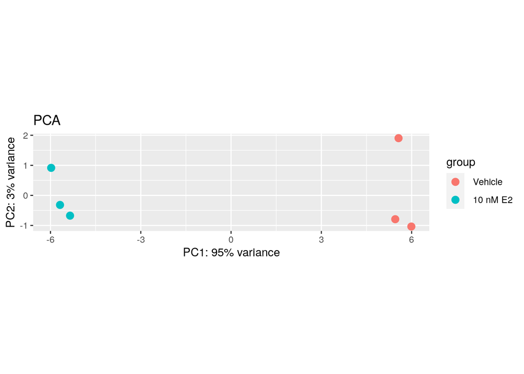

```r
# VST transformation
vsd <- vst(dds, blind=FALSE)

# Plotting PCA
plotPCA(vsd, intgroup="treatment") + ggtitle("PCA")
```

Principal component 1 clearly separates the samples according to the treatment.

### 2.3. Volcano plot

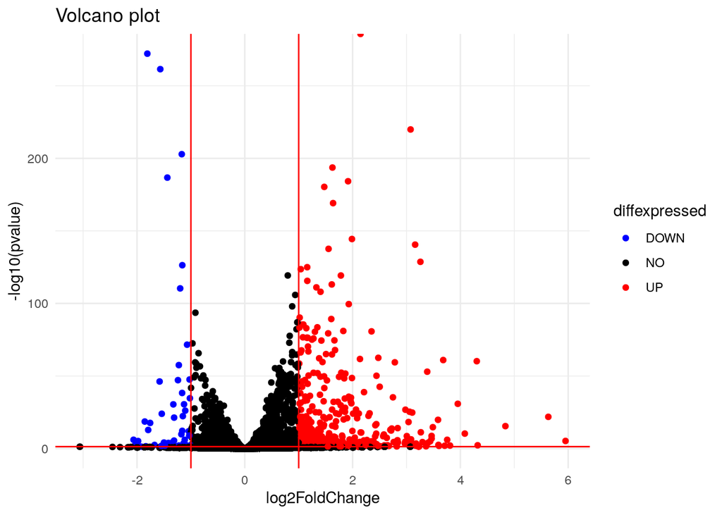

```r
# Adding a column with classification
res_table$diffexpressed <- "NO"
# If log2Foldchange > 1 and pval < 0.05, setting as "UP-regulated"
res_table$diffexpressed[res_table$log2FoldChange > 1 & res_table$pval < 0.05] <- "UP"
# If log2Foldchange < -1 and pval < 0.05, setting as "DOWN-regulated"
res_table$diffexpressed[res_table$log2FoldChange < -1 & res_table$pval < 0.05] <- "DOWN"

# Plotting volcano plot
ggplot(data=res_table, aes(x=log2FoldChange, y=-log10(pvalue), col=diffexpressed)) +
        geom_point() +
        theme_minimal() +
        scale_color_manual(values=c("blue", "black", "red")) +
        geom_vline(xintercept=c(-1, 1), col="red") +
        geom_hline(yintercept=-log10(0.05), col="red")+ ggtitle("Volcano plot")
```

There are more upregulated genes than downregulated genes after treatment with estrogen.

### 2.4. Heatmap

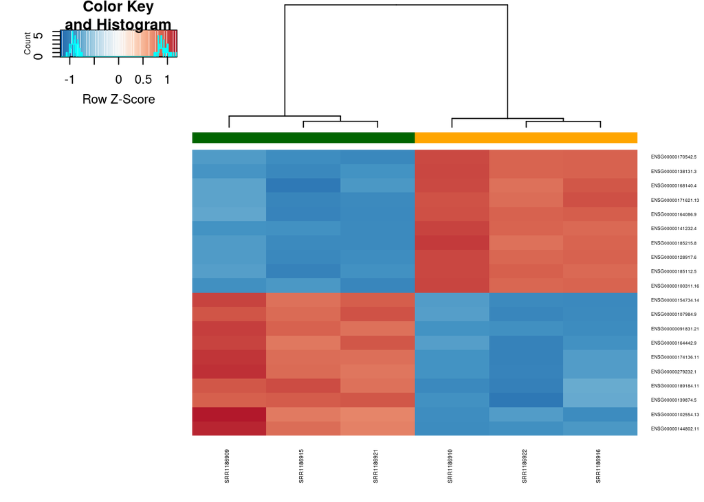

```r
# Rlog transformation
rld <- rlog( dds)

up_genes <- subset(res_table, res_table$diffexpressed=="UP")
top_up <- up_genes[order(up_genes$padj, decreasing = F),][1:10,]
down_genes <- subset(res_table, res_table$diffexpressed=="DOWN")
top_down <- down_genes[order(down_genes$padj, decreasing = F),][1:10,]
sigGenes <- c(rownames(top_up), rownames(top_down))

# Plotting heatmap
heatmap.2( assay(rld)[ sigGenes, ],Rowv=F, scale="row",
       trace="none", dendrogram="column",
       col = colorRampPalette( rev(brewer.pal(9, "RdBu")) )(255),
       ColSideColors = c( "darkgreen", "orange" )[
         colData(rld)$treatment ] , cexRow=0.4, cexCol=0.5)
```

We can see which genes are most up- and down-regulated depending on the treatment.

### 2.5. Gene set enrichment analysis

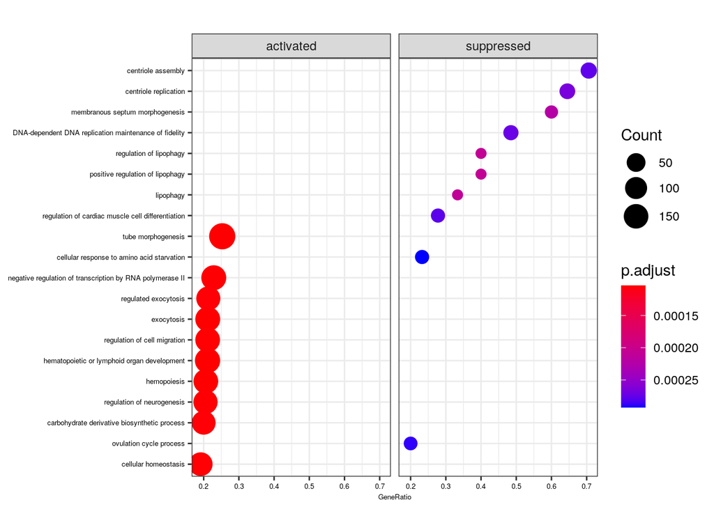

```r
organism <- "org.Hs.eg.db"

# Taking the stat values
original_gene_list <- res_table$stat

# Naming the vector
names(original_gene_list) <- gsub("\\..*","",(rownames(res_table)))

# Omitting any NA values
gene_list<-na.omit(original_gene_list)

# Sorting the list in decreasing order
gene_list = sort(gene_list, decreasing = TRUE)

#Performing GSEA
gse <- gseGO(geneList=gene_list,
             ont ="BP",
             keyType = "ENSEMBL",
             nPerm = 10000,
             minGSSize = 3,
             maxGSSize = 800,
             pvalueCutoff = 0.05,
             verbose = TRUE,
             OrgDb = organism,
             pAdjustMethod = "none")

# Plotting
dotplot(gse, showCategory=10, split=".sign", font.size = 5) + facet_grid(.~.sign)
```

- Chambard JC, Lefloch R, Pouysségur J, Lenormand P. ERK implication in cell cycle regulation. Biochim Biophys Acta. 2007 Aug;1773(8):1299-310. doi: 10.1016/j.bbamcr.2006.11.010. Epub 2006 Nov 17. PMID: 17188374.
- Chang F, Lee JT, Navolanic PM, Steelman LS, Shelton JG, Blalock WL, Franklin RA, McCubrey JA. Involvement of PI3K/Akt pathway in cell cycle progression, apoptosis, and neoplastic transformation: a target for cancer chemotherapy. Leukemia. 2003 Mar;17(3):590-603. doi: 10.1038/sj.leu.2402824. PMID: 12646949.
- Ji MX, Yu Q. Primary osteoporosis in postmenopausal women. Chronic Dis Transl Med. 2015 Mar 21;1(1):9-13. doi: 10.1016/j.cdtm.2015.02.006. PMID: 29062981; PMCID: PMC5643776.